# Data science per psicologi - demo 03.01

Corrado Caudek

2022-02-06

# Pacchetti

Carichiamo i pacchetti necessari. Se tali pacchetti non sono presenti sulla macchina, devono prima essere installati con la funzione `install.packages()`.

```r
suppressPackageStartupMessages({
  library("tidyverse")
  library("bayesplot")
  library("rio")
  library("here")
})

theme_set(bayesplot::theme_default(base_size = 12))
bayesplot::color_scheme_set("gray")
set.seed(84735)

knitr::opts_chunk$set(
  collapse = TRUE,
  tidy = 'styler',
  fig.width = 6,
  fig.asp = 0.618 # 1 / phi
)
```

# Importare i dati

La *working directory* del progetto che contiene questo script Rmd si può recuperare con la funzione

```r
here::here()
```

```
## [1] "/Users/corrado/_repositories/ds4psy_R_demos"
```

Questo percorso è ovviamente specifico al computer che sto usando in questo momento. Su qualsiasi altra macchina sarà diverso.

Sulla mia macchina, nella cartella `ds4psy_R_demos` è contenuta la cartella `data` dove si trova il file `data_mood.csv`. Importiamo i dati in R nel modo seguente:

```r
d <- rio::import(
  here::here("data", "data_mood.csv")
)
```

Si noti che la funzione

```r
here::here("data", "data_mood.csv")
```

non fa altro che stampare l’indirizzo assoluto, avendo specificato soltanto il percorso relativo alla corrente *working directory*.

L’istruzione precedente salva i dati nel data.frame `d`. Uso `glimpse()` per esaminare questo oggetto:

```r
glimpse(d)
```

```
## Rows: 1,188
## Columns: 44
## $ V1                  <int> 1, 2, 3, 4, 5, 6, 7, 8, 9, 10, 11, 12, 13, 14, 15,…
## $ vpn_nr              <int> 101, 101, 101, 101, 101, 101, 101, 101, 101, 101, …
## $ esm_id              <int> 10, 10, 10, 10, 10, 10, 10, 10, 10, 10, 10, 10, 10…
## $ group               <chr> "mdd", "mdd", "mdd", "mdd", "mdd", "mdd", "mdd", "…
## $ bildung             <chr> "abitur", "abitur", "abitur", "abitur", "abitur", …
## $ bdi                 <int> 25, 25, 25, 25, 25, 25, 25, 25, 25, 25, 25, 25, 25…
## $ nr_of_episodes      <int> 2, 2, 2, 2, 2, 2, 2, 2, 2, 2, 2, 2, 2, 2, 2, 2, 2,…
## $ nobs_mood           <int> 14, 14, 14, 14, 14, 14, 14, 14, 14, 14, 14, 14, 14…
## $ trigger_counter     <int> 5, 6, 7, 8, 10, 11, 12, 15, 16, 18, 20, 21, 22, 24…
## $ form                <chr> "Forecasting", "Forecasting", "Forecasting", "Fore…
## $ traurig_re          <dbl> 3.666667, 3.666667, 1.666667, 3.000000, 3.000000, …
## $ niedergeschlagen_re <dbl> 3.000000, 3.666667, 1.666667, 3.000000, 3.000000, …
## $ unsicher_re         <dbl> 2.333333, 3.666667, 2.333333, 3.000000, 2.333333, …
```

[output cut: 31 more lines]

Questi dati sono stati messi a disposizione da Zetsche et al. (2021); contengono 1188 righe e 44 colonne.

Ci focalizziamo qui sulla variabile `rrs_brood`. Questi sono i valori della scala *Ruminative Response Scale* (RRS) di Treynor, Gonzalez, e Nolen-Hoksema (2003), che è uno degli strumenti maggiormente impiegati in letteratura per la misurazione della ruminazione depressiva. La scala misura le due componenti della ruminazione, ossia “Rimuginazione” e “Riflessione”, e la componente “Depressione”. La variabile `rrs_brood` corrisponde alla sottoscala “Rimuginazione”.

Nel DataFrame `d`, i valori RRS-brood si ripetono tante volte, per ciascun partecipante, perché lo stesso partecipante è stato esaminato in momenti diversi e in condizioni diverse. Poniamoci innanzitutto il problema di recuparare un solo valore per ciascun partecipante:

```r
bysubj <- d %>%
  group_by(esm_id) %>%
  summarise(
    rrs_brood = mean(rrs_brood)
  )
head(bysubj)
```

```
## # A tibble: 6 × 2
##   esm_id rrs_brood
##    <int>     <dbl>
## 1      6        10
## 2      7        12
## 3      9         9
## 4     10        14
## 5     12        18
## 6     16        17
```

Otteniamo così un DataFrame con due colonne: il codice identificativo del partecipante e il valore sulla scala RRS-brood.

Lo scopo di questo esercizio è quello di descrivere la distribuzione dei valori `rrs_brood`.

```r
rrs_brood <-
  length(unique(d$esm_id))
```

Iniziamo chiedendoci quali sono le modalità della variabile `rrs_brood` nel presente campione:

```r
sort(unique(bysubj$rrs_brood))
```

```
##  [1]  5  6  7  8  9 10 11 12 13 14 15 16 17 18 19
```

Creaiamo ora una tabella che riporta la frequenza assoluta del numero di partecipanti che hanno ottenuto ciascuno dei valori `rrs_brood` elencati sopra:

```r
table(bysubj$rrs_brood)
```

```
##
##  5  6  7  8  9 10 11 12 13 14 15 16 17 18 19
##  4  8  5  6  6  7  6  3  4  5  2  3  4  3  1
```

Quattro partecipanti hanno ottenuto un valore RRS-brood uguale a 5, otto partecipanti un valore uguale a 6, …, un partecipante un valore uguale a 19.

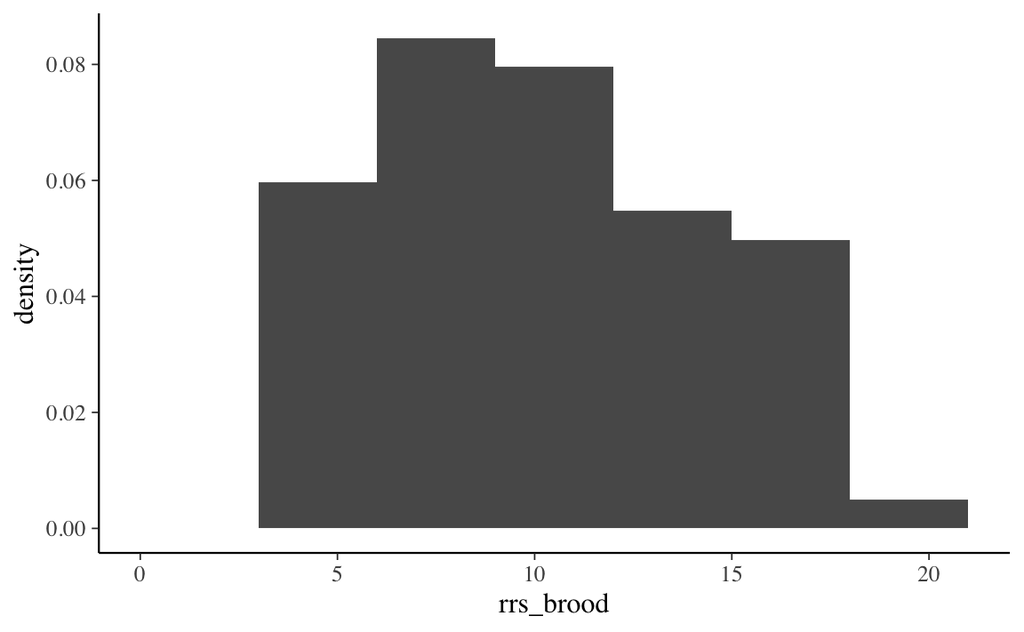

```r
bysubj %>%
  ggplot(aes(rrs_brood)) +
  geom_histogram(
    aes(y = ..density..),
    breaks = c(0, 3, 6, 9, 12, 15, 18, 21),
    closed = "right"
  )
```

Controlliamo. La seconda classe è (3-6]. In tale classe cadono

```r
sort(bysubj$rrs_brood)
```

```
##  [1]  5  5  5  5  6  6  6  6  6  6  6  6  7  7  7  7  7  8  8  8  8  8  8  9  9
## [26]  9  9  9  9 10 10 10 10 10 10 10 11 11 11 11 11 11 12 12 12 13 13 13 13 14
## [51] 14 14 14 14 15 15 16 16 16 17 17 17 17 18 18 18 19
```

12 osservazioni, ovvero una proporzione di casi pari a

```r
12 / length(bysubj$rrs_brood)
```

```
## [1] 0.1791045
```

L’altezza della barra dell’istogramma corrispondente alla classe (3-6] sarà dunque uguale a

```r
(12 / length(bysubj$rrs_brood)) / 3
```

```
## [1] 0.05970149
```

Questo valore corrisponde a quello rappresentato nell’istogramma precedente.

Se invece avessimo usato classi aperte a destra, avremmo ottenuto l’istogramma seguente:

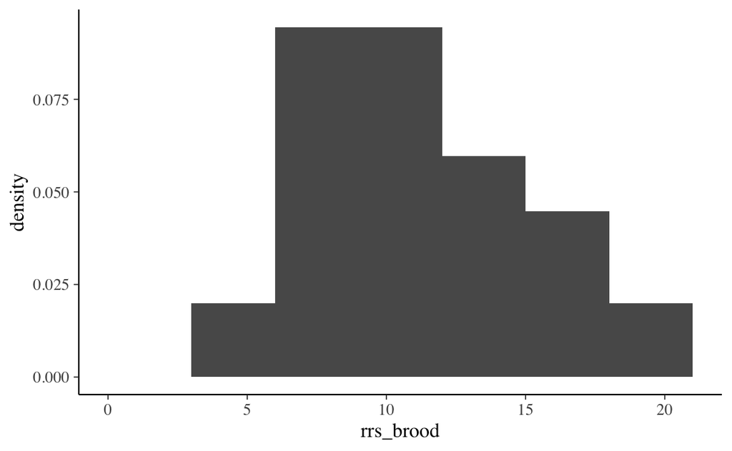

```r
bysubj %>%
  ggplot(aes(rrs_brood)) +
  geom_histogram(
    aes(y = ..density..),
    breaks = c(0, 3, 6, 9, 12, 15, 18, 21),
    closed = "left"
  )
```

Possiamo migliorare l’istogramma nel modo seguente:

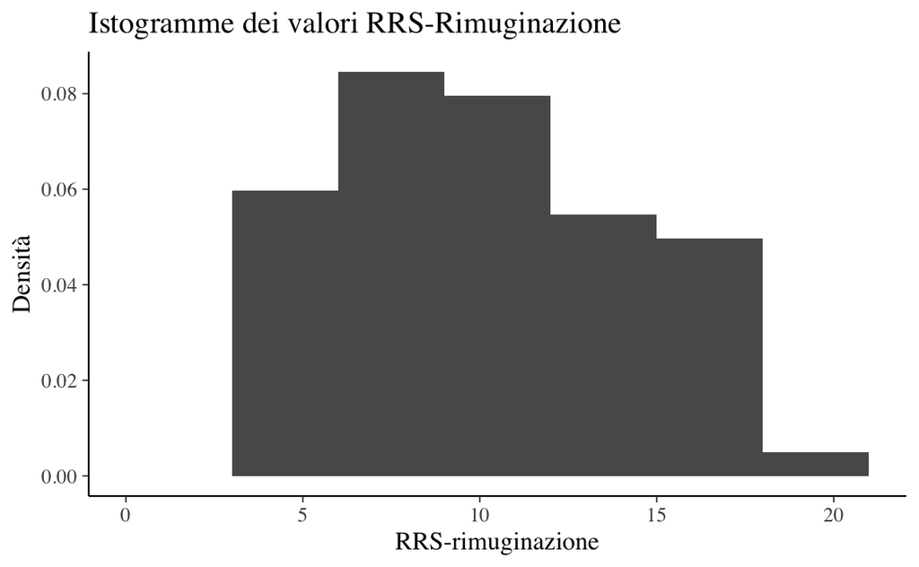

```r
bysubj %>%
  ggplot(aes(rrs_brood)) +
  geom_histogram(
    aes(y = ..density..),
    breaks = c(0, 3, 6, 9, 12, 15, 18, 21),
    closed = "right"
  ) +
  labs(
    title = "Istogramme dei valori RRS-Rimuginazione",
    x = "RRS-rimuginazione",
    y = "Densità"
  )
```